# Индивидуальный проект. 1 этап

Операционные системы

Шулуужук А.В.

Российский университет дружбы народов, Москва, Россия

25 февраля 2023

# Цели и задачи

Размещение на Github pages заготовки для персонального сайта.

# Выполнение индивидуального проекта

1. Скачиваем архив, распакуем его и скопируем исполняемый файл

[figure not shown]

папка bin

## Выполнение индивидуального проекта

2. Cоздаем репозиторий blog, используя шаблон, и клонируем его

[figure not shown]

репозитоий blog

## Выполнение индивидуального проекта

3. Проводим команду ~/bin/hugo server, получаем ссылку на локальный сайт

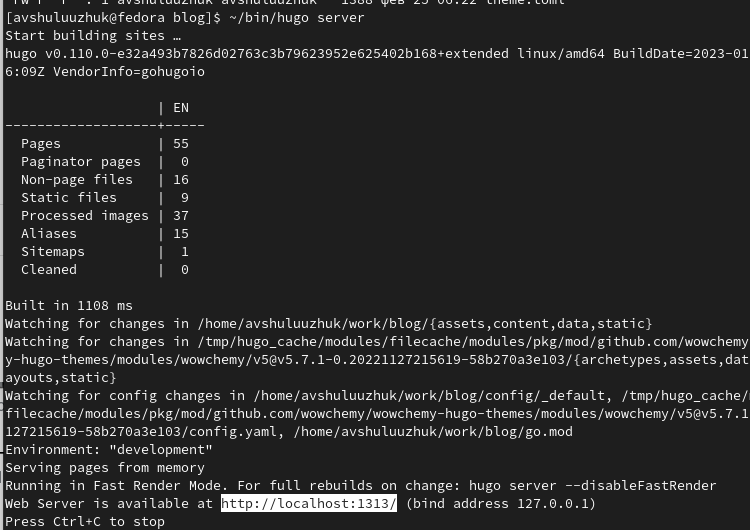

ссылка на локальный сайт

## Выполнение индивидуального проекта

4. Переходим на этот сайт через браузер

[figure not shown]

локальный сайт

## Выполнение индивидуального проекта

5. Для того, чтобы убрать синий блок с текстом нужно перейти в каталог blog-content-index.md

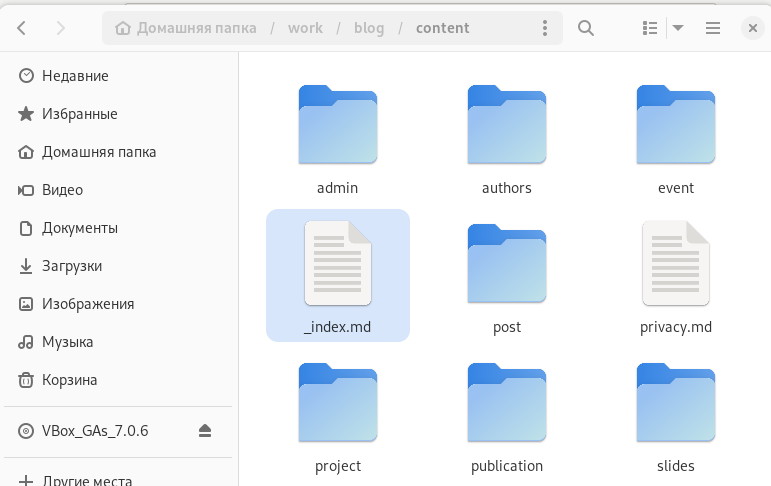

файл _index.md

## Выполнение индивидуального проекта

6. В данном файле следует редактировать текст. Удалаяем следующий набор текста

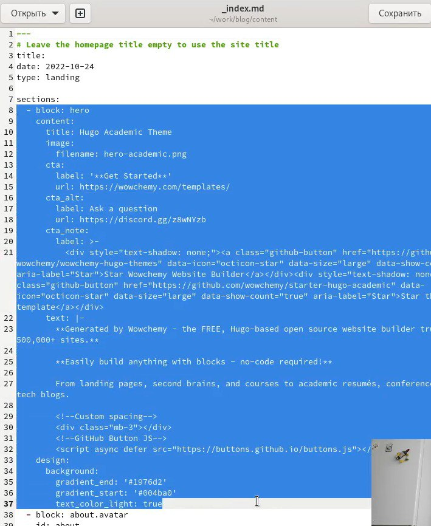

редактирование _index.md

## Выполнение индивидуального проекта

7. После удаления данного текста на сайте сразу исчезнет синий блок

[figure not shown]

сайт после редактирования

## Выполнение индивидуального проекта

8. На github создаем еще один новый репозиторий со специальным названием avshuluuzhuk.github.io и клонируем его

[figure not shown]

новый репозиторий

## Выполнение индивидуального проекта

9. В новом каталоге переключаемся на ветку main, создаем пустой файл README.md и отправляем его на github для активации репозитория

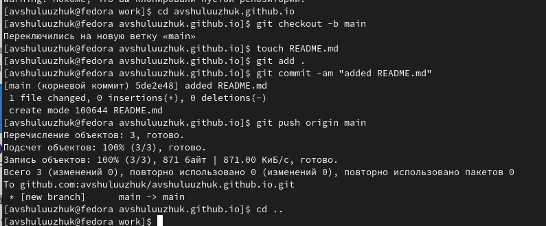

создание пустого файла и добавление на github

## Выполнение индивидуального проекта

10. Запускаем mc и редактируем .gitignore. Комментируем #public

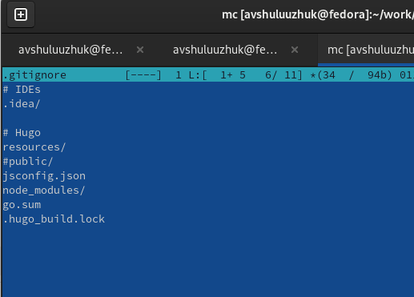

комментирование public

## Выполнение индивидуального проекта

11. Командой “cat .gitignore” проверяем файл и после чего снова повторяем команду для подключения каталога public к репозиторию.

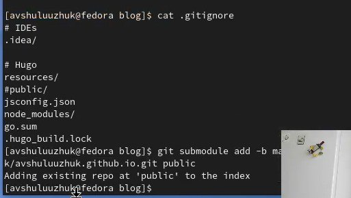

подключение каталога к новому репозиторию

## Выполнение индивидуального проекта

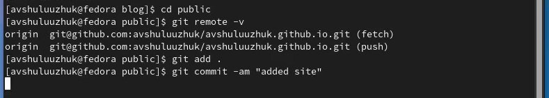

загрузка файлов на сервер

## Выполнение индивидуального проекта

13. Обновляем репозиторий и проверяем добавление файлов

[figure not shown]

сайт с репозиторием

## Выполнение индивидуального проекта

14. Копируем ссылку на новый сайт и переходим на него

[figure not shown]

переход на сайт

# Выводы

В ходе выполнения первого этапа индивидуального проекта я научилась размещать на github pages заготовки для персонального сайта